# World Health Organisation: Global Suicide Trends & Analysis

Anastasiia Livochka

1 Mar 2019

```r
library(tidyverse)
library(ggalt)
library(countrycode)
library(gridExtra)
library(broom)
```

```r
rates <- read.csv("master.csv")
```

# 1 Data preparation

```r
rates$sex <- sapply(rates$sex, function(x) {ifelse(x == "male", 1, 0)})
names(rates)[3] <- "male"
names(rates)[11] <- "gdp_per_capita"
names(rates)[10] <- "gdp_year"
rates$gdp_year <- as.numeric(rates$gdp_year)
```

# 2 How was the suicide rate changing over years?

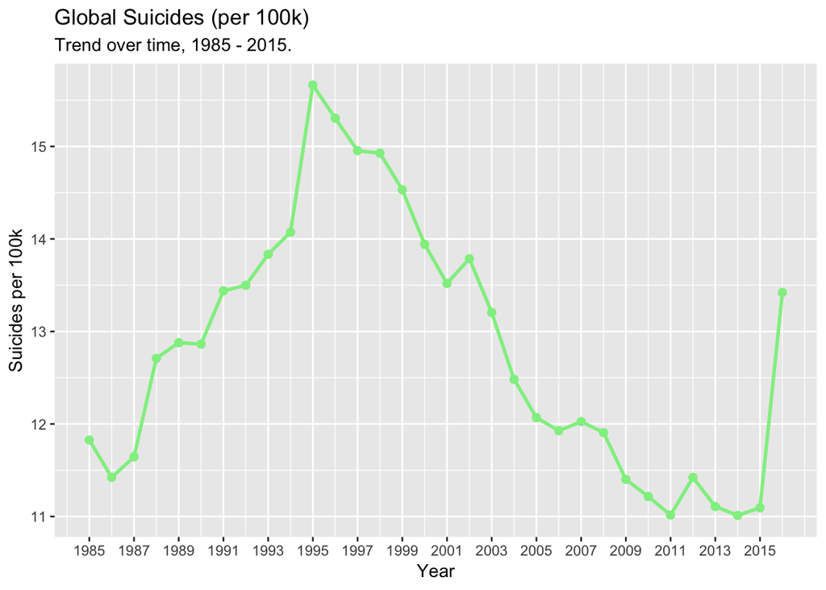

```r
rates %>%
  group_by(year) %>%
  summarize(suicides.100k.pop = mean(suicides.100k.pop)) %>%
  ggplot(aes(x = year, y = suicides.100k.pop)) +
  geom_line(col = "lightgreen", size = 1) +
  geom_point(col = "lightgreen", size = 2) +
  labs(title = "Global Suicides (per 100k)",
       subtitle = "Trend over time, 1985 - 2015.",
       x = "Year",
       y = "Suicides per 100k") +
  scale_x_continuous(breaks = seq(1985, 2015, 2)) +
  scale_y_continuous(breaks = seq(10, 20))
```

```r
grouped <- rates %>%
  group_by(year, country) %>%
  summarize(suicide.rates = sum(suicides_no/population) * 10000)
```

**$H_0: \mu_{1994} = \mu_{2008}$, $H_1: \mu_{1994} > \mu_{2008}$, $\sigma_1^2, \sigma_2^2 unknown$**

We test whether the average suicide rate in 1994 was bigger than in 2008 ar significance level **$\alpha$ = 0.05**

```r
year1 <- grouped$suicide.rates[grouped$year == 1994]
year2 <- grouped$suicide.rates[grouped$year == 2008]
t.test(year1, alternative = 'greater', mu = mean(year2))
```

```
##
##  One Sample t-test
##
## data:  year1
## t = 1.7531, df = 67, p-value = 0.04208
## alternative hypothesis: true mean is greater than 14.28926
## 95 percent confidence interval:
##  14.41554      Inf
## sample estimates:
## mean of x
##  16.88786
```

Conclusion 1: **p < $\alpha$**, so we reject null hypothesis. The average suicide rate in 1994 was bigger than in 2008.

# 3 Is there a difference betwwen suicides rate in Russia and Ukraine?

```r
countries <- rates %>%
  group_by(year, country)  %>%
  summarize(suicides.rates = sum(suicides_no/population) * 10000)
```

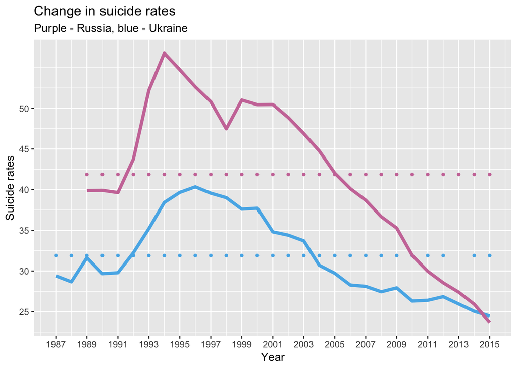

```r
ggplot(fill = countries$country) +
  geom_line(data = subset(countries, country=="Ukraine"), aes(x = year, y = suicides.rates), color = "#56B4E9", size=1.5) +
  geom_point(data = subset(countries, country=="Ukraine"), aes(x = year, y = mean(suicides.rates)), size=1, color="#56B4E9") +
  geom_line(data = subset(countries, country=="Russian Federation"), aes(x = year, y = suicides.rates), color = "#CC79A7", size=1.5) +
  geom_point(data = subset(countries, country=="Russian Federation"), aes(x = year, y = mean(suicides.rates)), color = "#CC79A7", size=1)+
  scale_x_continuous(breaks = seq(1985, 2015, 2))  +
  scale_y_continuous(breaks = seq(10, 50, by=5)) +
  labs(title = "Change in suicide rates",
       subtitle = "Purple - Russia, blue - Ukraine",
       x = "Year",
       y = "Suicide rates")
```

```r
ukraine <- subset(countries, country=="Ukraine")$suicides.rates
russia <- subset(countries, country=="Russian Federation")$suicides.rates
```

**$H_0: \mu_{russia} = \mu_{ukraine}$, $H_1: \mu_{russia} > \mu_{ukraine}$, $\sigma_1^2, \sigma_2^2$ unknown**

We test whether the average suicide rate in Russia is bigger than in Ukraine at significance level **$\alpha$ = 0.05**

```r
t.test(russia, alternative='greater', mu=mean(ukraine))
```

```
##
##  One Sample t-test
##
## data:  russia
## t = 5.4543, df = 26, p-value = 5.087e-06
## alternative hypothesis: true mean is greater than 31.89865
## 95 percent confidence interval:
##  38.75248      Inf
## sample estimates:
## mean of x
##   41.8709
```

Conclusion 2: **p < $\alpha$**, so we reject null hypothesis. The average suicide rate in Russia is bigger than in Ukraine.

# 4 How was the suicide rate changing over generations?

```r
generations <- rates %>%
  group_by(generation, country,  year) %>%
  summarize(suicides.rates = sum(suicides_no/population) * 10000)
```

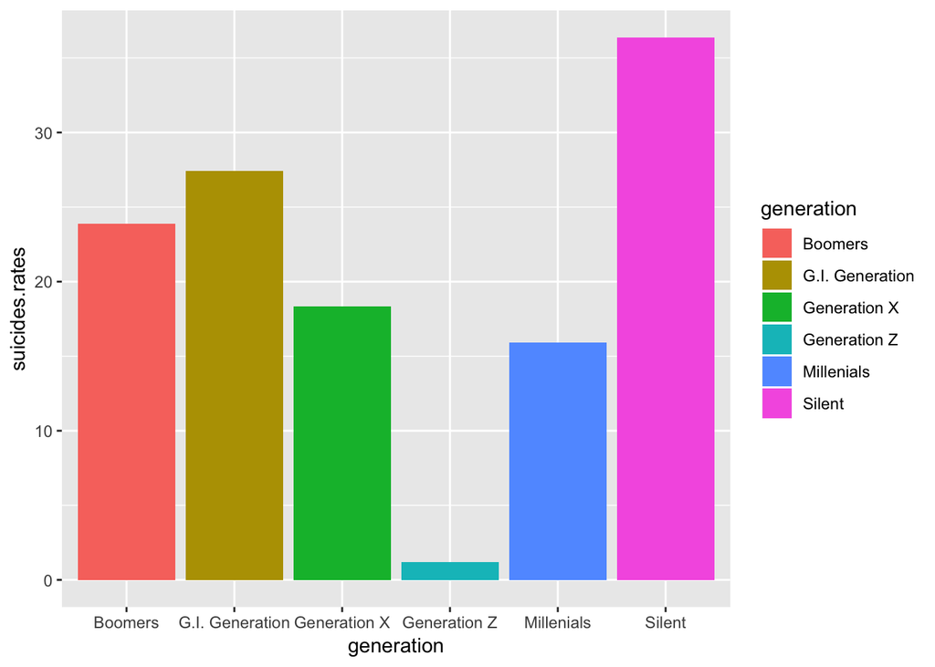

```r
ggplot(generations, aes(x=generation, y=suicides.rates)) +
    geom_bar(aes(fill=generation),   # fill depends on cond2
             stat="identity",
             position=position_dodge())
```

```r
boomers <- generations$suicides.rates[generations$generation == "Boomers"]
gen_x <- generations$suicides.rates[generations$generation == "Generation X"]
```

**$H_0: \mu_{genx} = \mu_{boomers}$, $H_1: \mu_{genx} < \mu_{boomers}$, $\sigma_1^2, \sigma_2^2 unknown$**

We test whether the average suicide rate among GenX equals to the one among Boomers or is less at significance level **$\alpha$ = 0.05**

```r
t.test(gen_x, alternative = "less", mu=mean(boomers))
```

```
##
##  One Sample t-test
##
## data:  gen_x
## t = -6.8748, df = 2320, p-value = 3.976e-12
## alternative hypothesis: true mean is less than 3.294364
## 95 percent confidence interval:
##      -Inf 3.005526
## sample estimates:
## mean of x
##  2.914636
```

Conclusion 3: **p < $\alpha$**, so we reject null hypothesis. The average suicide rate among GenX is less than among Boomers.

# 5 What about gdp per capita influence?

```r
gdps <- rates %>%
  group_by(year, country) %>%

  summarize(gdp.rates = round(mean(gdp_year) /sum(population) *1000), suicides.rates =  sum(suicides_no/population) * 100)
```

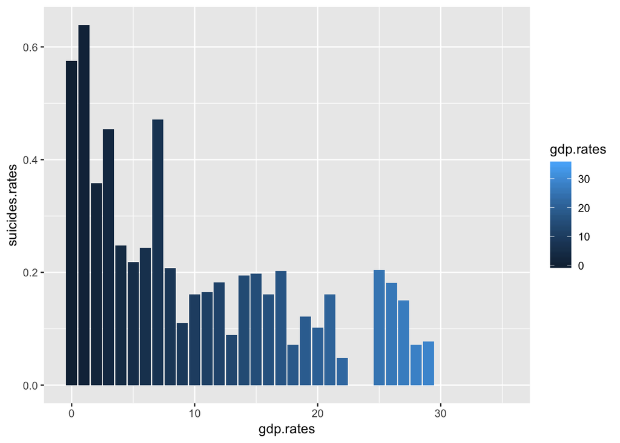

```r
ggplot(gdps, aes(x = gdp.rates, y = suicides.rates)) +
  geom_bar(aes(fill=gdp.rates),   # fill depends on cond2
             stat="identity",
             position=position_dodge())
```

```r
low.gdp <- gdps$suicides.rates[gdps$gdp.rates <= 12]
high.gdp <- gdps$suicides.rates[gdps$gdp.rates > 12]
```

**$H_0: \mu_{low} = \mu_{high}$, $H_1: \mu_{low} > \mu_{high}$, $\sigma_1^2, \sigma_2^2 unknown$**

We test whether the average suicide rate among people with low gdp per capita equals to the one among the ones with high orit is greater at significance level **$\alpha$ = 0.05**

```r
t.test(low.gdp, alternative = "greater", mu=mean(high.gdp))
```

```
##
##  One Sample t-test
##
## data:  low.gdp
## t = 42.448, df = 2216, p-value < 2.2e-16
## alternative hypothesis: true mean is greater than 0.05290692
## 95 percent confidence interval:
##  0.1542535       Inf
## sample estimates:
## mean of x
## 0.1583408
```

Conclusion 4: **p < $\alpha$**, so we reject null hypothesis. The average suicide rate among people with low gdp per capita is greater than among the ones with high.